# Part III 금융 데이터 과학

3부는 금융 데이터 과학을 위한 기초적인 테크닉과 방법론 그리고 패키지에 대한 내용입니다. 시각화와 같은 주제와 사이킷런 등의 패키지가 모두 중요합니다.

# 7장 데이터 시각화

> 그림을 사용하라. 천 마디 말보다 낫다.
> - 아서 브리즈먼

```python
import matplotlib as mpl
```

```python
mpl.__version__
```

```
'3.7.0'
```

```python
import matplotlib.pyplot as plt # 메인 서브패키지를 plt라는 이름으로 임포트
```

```python
plt.style.use('seaborn') # seaborn 플롯 스타일 설정
```

```python
mpl.rcParams['font.family'] = 'serif' # 모든 플롯의 폰트를 serif로 설정
```

```python
%matplotlib inline
```

### 7.1.1 1차원 데이터

가장 기본적이고 강력한 플롯 명령은 `plot` 함수입니다. 이 함수는 두 가지 숫자 집합이 필요합니다.

- $x$값: 가로축의 값을 담고 있는 배열이나 리스트
- $y$값: 세로축의 값을 담고 있는 배열이나 리스트

물론 $x$값과 $y$값의 개수는 같아야 합니다.

```python
import numpy as np
```

```python
np.random.seed(1000)
```

```python
y = np.random.standard_normal(20)
```

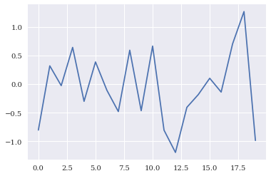

```python
x = np.arange(len(y))
plt.plot(x, y)
```

만약 `plot` 함수의 인수로 `ndarray` 객체를 넘기는 경우에는 함수가 이를 감지하여 자동으로 처리하므로 $x$값에 대한 추가 정보를 제공하지 않아도 됩니다. 만약 $y$값만 있으면 인덱스값을 $x$값으로 사용합니다. 따라서 다음 한 줄짜리 코드도 앞의 코드와 같은 그림을 그려줍니다.

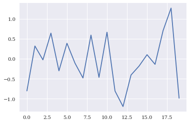

```python
plt.plot(y)
```

> **TIP** NumPy 배열과 matplotlib  
> 넘파이 `ndarray` 객체를 `matplotlib` 함수에 바로 넘길 수 있으며, 이때는 `ndarray` 객체에서 단순한 플롯을 위한 자료구조를 자동으로 파악할 수 있습니다. 하지만 너무 크거나 복잡한 배열을 인수로 사용하지 않도록 주의해야 합니다.

대부분의 `ndarray` 메서드는 결과로 `ndarray` 객체를 출력하기 때문에 객체에 한 개 이상의 함수를 호출하여 `plot` 함수로 넘기는 것도 가능합니다. 앞의 예제에 사용된 `ndarray` 객체에 `cumsum()` 메서드를 호출하면 자료의 누적합계를 구하므로 그림 결과도 달라집니다.

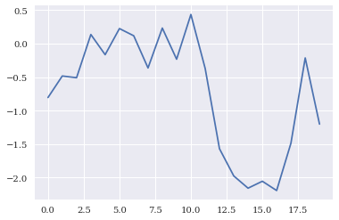

```python
plt.plot(y.cumsum())
```

기본으로 제공되는 플롯 스타일은 보고서나 출판물을 위한 일반적인 요구조건에 맞지 않습니다. 예를 들어 사용하는 폰트를 레이텍(LaTex) 폰트와 호환되는 것으로 바꾸길 원할 수도 있고, 그림 축에 레이블을 붙이거나 가독성을 높이기 위해 그리드를 추가해야 할 수도 있습니다. 이런 점을 고려해 맷플롯립에서는 스타일을 변경하기 위한 다양한 함수를 제공합니다. 일부 함수는 쉽게 사용할 수 있고 일부는 사용하기 복잡할 수 있습니다. 예를 들어 축 또는 그리드와 레이블을 조정하는 함수는 사용하기 어렵지 않죠.

```
(-0.9500000000000001, 19.95, -2.322818663749045, 0.5655085808655865)
```

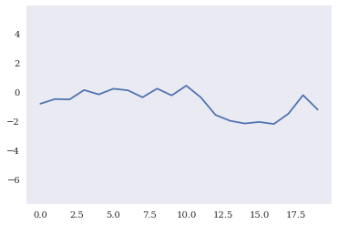

```python
plt.plot(y.cumsum())
plt.grid(False)
plt.axis('equal')
```

`plt.axis()` 함수의 다른 옵션을 표에 정리하면 다음과 같습니다. 대부분은 문자열 인수로 넘겨야 합니다.

| 인수 | 설명 |
| --- | --- |
| 인수가 없는 경우 | 현재 축의 한계값을 반환 |
| `off` | 축 선과 레이블을 없앰 |
| `equal` | 가로축과 세로축의 스케일을 같게 함 |
| `scaled` | 가로축과 세로축의 스케일이 같아지도록 크기 자체를 조정 |
| `tight` | 모든 자료가 보이도록 축 범위를 조밀하게 조정 |
| `image` | 모든 자료가 보이도록 축 범위를 자료의 극한값으로 조정 |
| `[xmin, xmax, ymin, ymax]` | 주어진 리스트값으로 축 범위 조정 |

또한 `plt.xlim()` 함수와 `plt.ylim()` 함수를 사용하면 가로축과 세로축의 범위를 직접 설정할 수 있습니다.

```
(-3.1915310617211072, 1.4342209788376488)
```

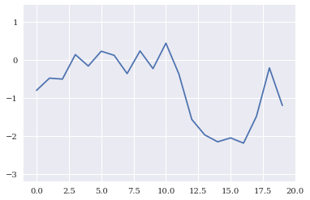

```python
plt.plot(y.cumsum())
plt.xlim(-1, 20)
plt.ylim(np.min(y.cumsum()) -1, np.max(y.cumsum()) + 1)
```

가독성을 위해 제목이나 $x$값, $y$값을 설명하는 레이블을 추가할 수 있습니다. 각각 `plt.title()`, `plt.xlabel()`, `plt.ylabel()` 함수를 사용합니다. `plot()` 함수는 아무런 설정이 없다면 이산 데이터 값이 주어져도 연속된 선으로 그립니다. 점을 그리는데 다른 스타일 옵션을 적용할 수도 있습니다. 다음 코드에 따라 두께 1.5의 파란색 선 위에 빨간색 점을 그려보겠습니다.

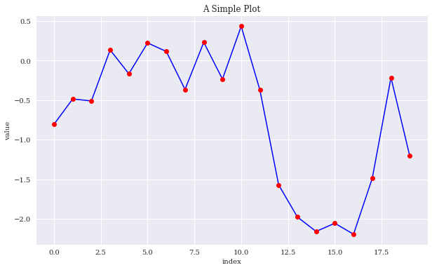

```python
plt.figure(figsize=(10, 6)) # 그림의 크기 증가
plt.plot(y.cumsum(), 'b', lw=1.5) # 두께 1.5의 파란색 선
plt.plot(y.cumsum(), 'ro') # 붉고 굵은 원
plt.xlabel('index') # x축 레이블
plt.ylabel('value') # y축 레이블
plt.title('A Simple Plot') # 제목
```

`plt.plot()` 함수에서는 다음 표와 같은 색깔 이름의 약자를 사용할 수 있습니다.

| 약자 | 색깔 |
| --- | --- |
| `b` | 파란색 |
| `g` | 초록색 |
| `r` | 빨간색 |
| `c` | 청록색(cyan) |
| `m` | 자홍색(magenta) |
| `y` | 노란색 |
| `k` | 검은색 |
| `w` | 흰색 |

`plt.plot()` 함수에서 선과 점의 스타일은 아래 표에 정리된 기호를 사용해 표시합니다.

| 글자 | 표시 |
| --- | --- |
| `-` | 실선 |
| `--` | 대시선 |
| `-.` | 대시-점선 |
| `:` | 점선 |
| `.` | 점 |
| `,` | 픽셀 |
| `o` | 원 |
| `v` | 아래쪽 삼각형 |
| `^` | 위쪽 삼각형 |
| `<` | 왼쪽 삼각형 |
| `>` | 오른쪽 삼각형 |
| `1` | 아래쪽 삼각형 |
| `2` | 위쪽 삼각형 |
| `3` | 왼쪽 삼각형 |
| `4` | 오른쪽 삼각형 |
| `s` | 사각형 |
| `p` | 오각형 |
| `*` | 별 |
| `h` | 육각형 1 |
| `H` | 육각형 2 |
| `+` | 덧셈 기호 |
| `x` | 곱셈 기호 |
| `D` | 다이아몬드 |
| `d` | 가는 다이아몬드 |
| `\|` | 브이라인(Vline) |
| `_` | 에이치라인(Hline) |

색깔 약자와 점/선 스타일 기호의 조합도 가능합니다. 이런 방식으로 표시하면 여러 개의 다른 자료들을 잘 구별할 수 있습니다. 나중에 보겠지만 이렇게 지정된 플롯 스타일은 범례(legend)에도 반영됩니다.

### 7.1.2 2차원 데이터

1차원 데이터를 그리는 일은 특별한 경우고 일반적으로 데이터 집합은 여러 개로 분리된 하위 자료들의 모음으로 이루어져 있습니다. 이러한 데이터 집합을 다룰 때도 1차원 데이터와 같은 형태로 맷플롯립을 사용하면 되지만 몇 가지 추가적인 고려를 해야 할 때도 있습니다. 예를 들어 두 개의 데이터 집합이 같은 $x$축 혹은 $y$축 축척을 쓸 수 없을 수도 있습니다. 또 다른 예는 두 개의 자료를 서로 다른 방법으로, 예를 들어 하나는 선 플롯으로 그리고 다른 하나는 막대 플롯으로 시각화하고 싶은 경우입니다.  
다음은 표준정규분포를 가지는 $20\times 2$ 크기의 의사 난수를 `ndarray`로 생성하는 코드입니다. 생성된 배열에 대해 `cumsum()` 메서드를 호출하면 0번 축(첫 번째 차원)을 따라 누적합계를 구합니다.

```python
y = np.random.standard_normal((20, 2)).cumsum(axis=0)
```

일반적으로 `plt.plot()`에는 2차원 배열도 인수로 넘길 수 있습니다. 이 명령은 자동으로 자료를 분석하여 담겨진 자료를 1번 축, 즉 두 번째 차원을 따라 두 개로 분리하고 그려줍니다.

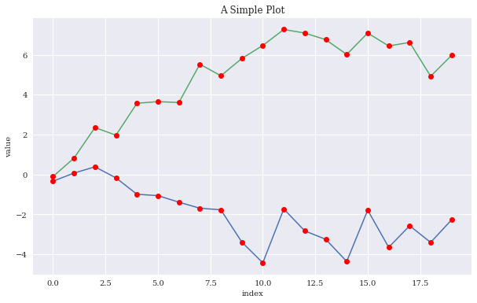

```python
plt.figure(figsize=(10, 6))
plt.plot(y, lw=1.5)
plt.plot(y, 'ro')
plt.xlabel('index')
plt.ylabel('value')
plt.title('A Simple Plot')
```

이 경우 가독성을 높이기 위해 추가로 주석 기호(annotation)를 달 수도 있습니다. 각 자료에 레이블을 붙이고 범례에 이를 나열할 수 있습니다. `plt.legend()` 함수는 범례의 위치를 지정하는 인수를 받습니다. 인수의 값이 0이면 범례에 의해 가려져서 보이지 않는 자료의 수가 최소가 되도록 최적의 범례 위치를 자동으로 계산합니다. 다음 그림에서는 두 개의 자료를 범례와 같이 표시했습니다. 생성하는 코드에서는 `ndarray` 객체를 한꺼번에 넘기지 않고 `y[:, 0]`, `y[:,1]`과 같이 분리하여 레이블을 붙였습니다.

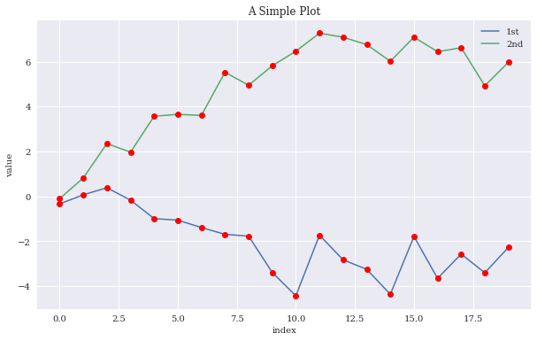

```python
plt.figure(figsize=(10, 6))
plt.plot(y[:, 0], lw=1.5, label='1st')
plt.plot(y[:, 1], lw=1.5, label='2nd')
plt.plot(y, 'ro')
plt.legend(loc=0)
plt.xlabel('index')
plt.ylabel('value')
plt.title('A Simple Plot')
```

`plt.legend()`의 추가 위치 인수를 아래 표에 표시했습니다.

| `loc` 인수 | 설명 |
| --- | --- |
| 기본값 | 오른쪽 위 |
| `0` | 가능한 최적의 위치 |
| `1` | 오른쪽 위 |
| `2` | 왼쪽 위 |
| `3` | 왼쪽 아래 |
| `4` | 오른쪽 아래 |
| `5` | 오른쪽 |
| `6` | 왼쪽 중앙 |
| `7` | 오른쪽 중앙 |
| `8` | 중앙 아래 |
| `9` | 중앙 위 |
| `10` | 중앙 |

동일한 금융 위험 요인을 여러 번 시뮬레이션하는 경우와 같이 비슷한 크기의 여러 데이터를 그릴 때는 하나의 $y$축을 써도 되지만, 크기가 전혀 다른 여러 데이터를 그릴 때는 하나의 $y$축만 써서는 시각적인 정보를 제대로 표시하기 어렵습니다. 예를 들어 위의 예제에서 데이터 하나를 100배 더 크게 하여 다시 그려보겠습니다.

```python
y[:, 0] = y[:, 0] * 100
```

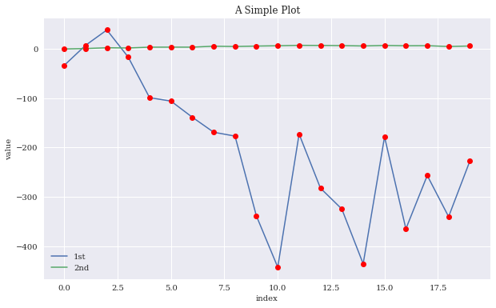

```python
plt.figure(figsize=(10, 6))
plt.plot(y[:, 0], lw=1.5, label='1st')
plt.plot(y[:, 1], lw=1.5, label='2nd')
plt.plot(y, 'ro')
plt.legend(loc=0)
plt.xlabel('index')
plt.ylabel('value')
plt.title('A Simple Plot')
```

위 그림을 보면 알 수 있듯이 첫 번째 데이터는 시각적으로 읽을 만하지만 두 번째 데이터는 축척으로 인해 거의 직선으로 보입니다. 다시 말해 두 번째 데이터의 정보는 '시각적으로 손실'된 상태입니다. 스케일링을 통해 데이터를 재조정하지 않고 이 문제를 해결하는 두 가지 방법이 있습니다.

- 두 개의 $y$축을 사용하는 방법 (좌/우)
- 두 개의 서브플롯(subplot)을 사용하는 방법 (좌/우 혹은 상/하)

우선 $y$축을 하나 더 사용하는 경우를 소개합니다. 아래 그림을 보면 $y$축이 두 개입니다. 왼쪽은 첫 번째 자료를 위한 것이고, 오른쪽의 축이 두 번째 데이터를 위한 것입니다. 범례는 두 개가 존재하게 됩니다.

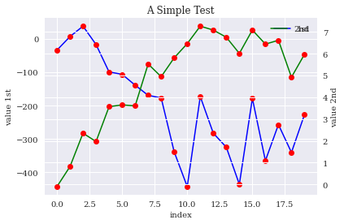

```python
fig, ax1 = plt.subplots() # figure 객체와 axis 객체 정의
plt.plot(y[:, 0], 'b', lw=1.5, label='1st')
plt.plot(y[:, 0], 'ro')
plt.legend(loc=0)
plt.xlabel('index')
plt.ylabel('value 1st')
plt.title('A Simple Test')

ax2 = ax1.twinx() # x축을 공유하는 두 번째 axis 객체를 생성합니다
plt.plot(y[:, 1], 'g', lw=1.5, label='2nd')
plt.plot(y[:, 1], 'ro')
plt.legend(loc=0)
plt.ylabel('value 2nd')
```

이 코드에서 중요한 부분은 축(axis)을 다루는 부분입니다. 다음이 중요한 코드입니다.

```
fig, ax1 = plt.subplots()
ax2 = ax1.twinx()
```

`plt.subplots()` 함수를 사용하면 `figure`나 `subplot` 등의 하부 플롯 객체에 직접 접근할 수 있습니다. 이를 이용하면 첫 번째 서브플롯과 $x$축을 공유하는 두 번째 서브플롯을 생성할 수 있습니다. 위 그림이 그 두 서브플롯을 겹쳐서 그린 것이죠.  
이제 두 서브플롯을 구분하는 경우를 생각해보겠습니다. 이 방식은 아래 그림에서 볼 수 있듯이 두 개의 자료를 다루는 데 있어 자유도를 높여줍니다.

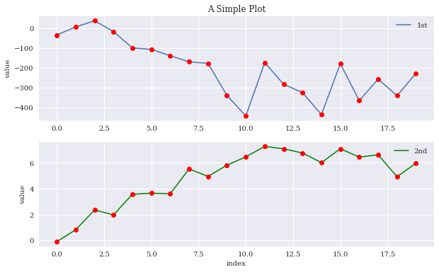

```python
plt.figure(figsize=(10, 6))
plt.subplot(211) # 위쪽 서브플롯 1을 정의합니다
plt.plot(y[:, 0], lw=1.5, label='1st')
plt.plot(y[:, 0], 'ro')
plt.legend(loc=0)
plt.ylabel('value')
plt.title('A Simple Plot')
plt.subplot(212) # 아래쪽 서브플롯 2를 정의합니다
plt.plot(y[:, 1], 'g', lw=1.5, label='2nd')
plt.plot(y[:, 1], 'ro')
plt.legend(loc=0)
plt.xlabel('index')
plt.ylabel('value')
```

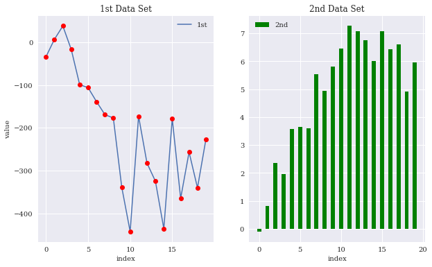

```python
plt.figure(figsize=(10, 6))
plt.subplot(121)
plt.plot(y[:, 0], lw=1.5, label='1st')
plt.plot(y[:, 0], 'ro')
plt.legend(loc=0)
plt.xlabel('index')
plt.ylabel('value')
plt.title('1st Data Set')
plt.subplot(122)
plt.bar(np.arange(len(y)), y[:, 1], width=0.5,
        color='g', label='2nd') # 바 차트 생성
plt.legend(loc=0)
plt.xlabel('index')
plt.title('2nd Data Set')
```

### 7.1.3 기타 플롯 유형

금융 분야에서 2차원 플롯을 사용할 때는 대부분의 데이터가 시계열 데이터이므로 선과 점으로 이루어진 플롯이 가장 많이 쓰입니다. 8장에서 금융 시계열 데이터에 대해 더 자세하게 다루도록 하고, 여기서는 2차원 자료인 경우만 고려하여 금융 분야에서 유용하게 사용되는 다른 시각화 방법을 살펴보겠습니다.  
첫번째는 산점도(스캐터플롯, scatter plot) 로 데이터 값중 하나를 $x$값으로, 다른 값을 그에 대응하는 $y$값으로 간주하는 것입니다. 아래 그림의 스캐터 플롯을 보죠. 두 개의 금융 시계열 데이터 수익률을 동시에 보일 때 사용할 수 있습니다. 예제를 위해 스캐터 플롯용 자료를 다시 생성합니다.

```python
y = np.random.standard_normal((1000, 2))
```

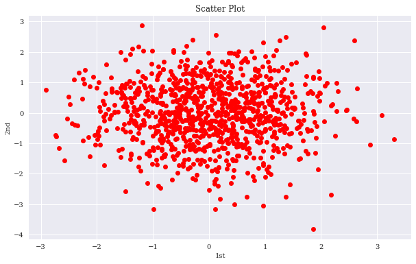

```python
plt.figure(figsize=(10, 6))
plt.plot(y[:, 0], y[:, 1], 'ro')
plt.xlabel('1st')
plt.ylabel('2nd')
plt.title('Scatter Plot')
```

맷플롯립 라이브러리는 스캐터플롯을 위한 별도의 `scatter()` 함수도 제공합니다. 이 함수는 `plot` 함수와 기본적인 사용법이 같지만 몇 가지 추가적인 기능을 제공합니다.

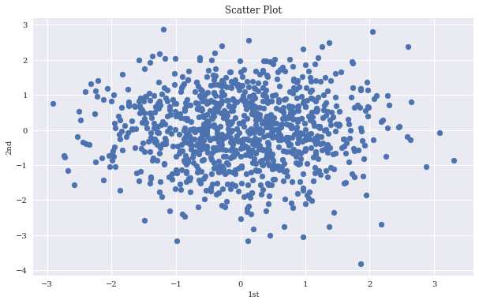

```python
plt.figure(figsize=(10, 6))
plt.scatter(y[:, 0], y[:, 1], marker='o')
plt.xlabel('1st')
plt.ylabel('2nd')
plt.title('Scatter Plot')
```

예를 들어 `scatter` 함수는 세 번째 차원을 추가할 수 있는데 이 값은 여러 가지 색을 사용하여 시각화할 수 있으며 색이 의미하는 값은 컬러바(colorbar)로 설명합니다. 다음 그림은 서로 다른 색상으로 세 번째 차원을 묘사하는 스캐터플롯을 보이고 있습니다. 이를 위해 0부터 10 사이의 정수를 가지는 세 번째 데이터를 임의로 생성했습니다.

```python
c = np.random.randint(0, 10, len(y))
```

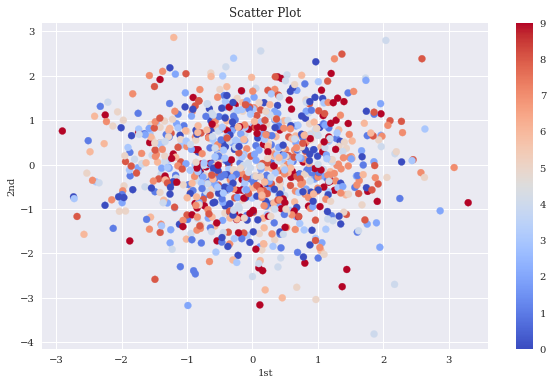

```python
plt.figure(figsize=(10, 6))
plt.scatter(y[:, 0], y[:, 1], c=c, # 세 번째 데이터 포함
            cmap='coolwarm', # 컬러맵
            marker='o') # 굵은 점 마커
plt.colorbar()
plt.xlabel('1st')
plt.ylabel('2nd')
plt.title('Scatter Plot')
```

다른 플롯 유형은 히스토그램(histogram)으로, 주로 금융자산 수익률을 나타내는 데 사용됩니다. 두 자료의 빈도를 같은 플롯에 붙여서 표시해보겠습니다.

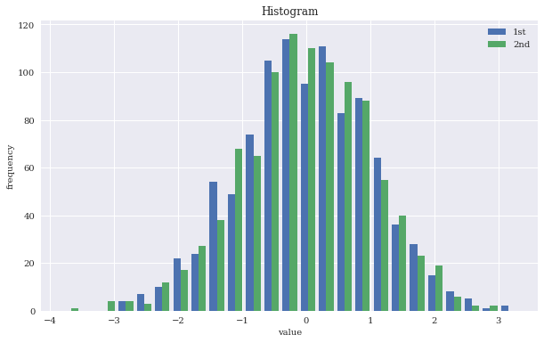

```python
plt.figure(figsize=(10, 6))
plt.hist(y, label=['1st', '2nd'], bins=25)
plt.legend(loc=0)
plt.xlabel('value')
plt.ylabel('frequency')
plt.title('Histogram')
```

히스토그램은 금융 분야에서 중요한 플롯 유형이므로 `plt.hist()` 함수에 대해 좀 더 자세히 살펴보도록 하겠습니다. 이 함수에는 다음과 같은 인수가 지원됩니다.

```
plt.hist(x, bins=None, range=None, density=False, weights=None, cumulative=False, bottom=None, histtype='bar', align='mid', orientation='vertical', rwidth=None, log=False, color=None, label=None, stacked=False, *, data=None, **kwargs)
```

아래 표에서 주요 인수를 설명합니다.

[output not shown]

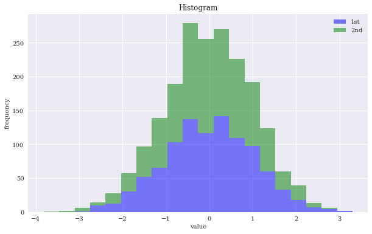

```python
plt.figure(figsize=(10, 6))
plt.hist(y, label=['1st', '2nd'], color=['b', 'g'],
         stacked=True, bins=20, alpha=0.5)
plt.legend(loc=0)
plt.xlabel('value')
plt.ylabel('frequency')
plt.title('Histogram')
```

또 하나의 유용한 플롯은 박스플롯(boxplot)입니다. 박스플롯은 히스토그램과 비슷하지만, 많은 데이터 집합의 특성을 동시에 정확하게 나타낼 수 있습니다.

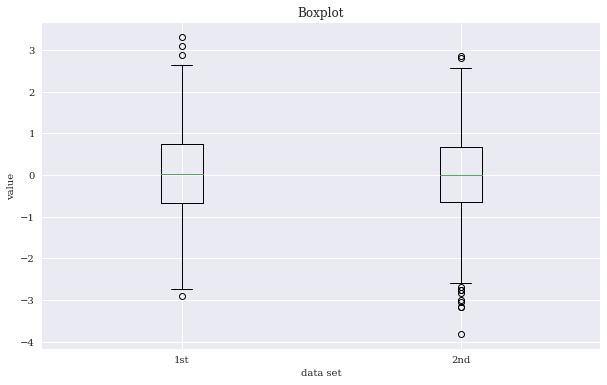

```python
fig, ax = plt.subplots(figsize=(10, 6))
plt.boxplot(y)
plt.setp(ax, xticklabels=['1st', '2nd']) # 개별 x 레이블 설정
plt.xlabel('data set')
plt.ylabel('value')
plt.title('Boxplot')
```

여기서 `setp` 함수는 플롯 객체의 속성을 설정하는 함수입니다. 예를 들어 다음과 같인 라인 플롯이 있다고 해보죠.

```
line = plt.plot(data, 'r')
```

이때 다음과 같은 코드를 이용하면 라인 스타일을 대시(dashed)로 변경할 수 있습니다.

```
plt.setp(line, linestyle='--')
```

이렇게 하면 플롯 객체(맷플롯립에서는 아티스트(artist) 객체라고 합니다)가 이미 생성된 이후에도 속성을 쉽게 변경할 수 있습니다.  
이 절에서 소개할 마지막 예제는 맷플롯립 갤러리에 있는 예제로 수학과 관련된 플롯입니다. 이 플롯은 함수의 상한과 하한 사이의 면적이 해당 함수의 정적분값과 같다는 것을 설명합니다. 예로 든 적분은 $\int_{\frac{1}{2}}^{\frac{3}{2}}\left(\frac{1}{2}e^x+1\right)\mathrm{d}x$입니다.  
아래 그림은 플롯 결과와 함께 맷플롯립에서 수학식을 플롯에 포함시키기 위해 레이텍을 사용할 수 있음을 보여줍니다.  
아래 코드를 하나씩 살펴보죠. 우선 적분하려는 함수와 적분 구간을 정의합니다.

```python
def func(x):
    return 0.5 * np.exp(x) + 1
a, b = 1/2, 3/2 # 적분 구간
x = np.linspace(0, 2) # 함수를 그릴 x값
y = func(x) # 함수를 그릴 y값
Ix = np.linspace(a, b) # 적분 구간의 x값
Iy = func(Ix) # 적분 구간의 y값
verts = [(a, 0)] + list(zip(Ix, Iy)) + [(b, 0)] # 다각형 그림 좌표를 나타내는 튜플 객체의 리스트
```

두 번째로 플롯을 그리고 여러 객체를 추가합니다.

```
[Text(0, 1.824360635350064, '$f(a)$'), Text(0, 3.2408445351690323, '$f(b)$')]
```

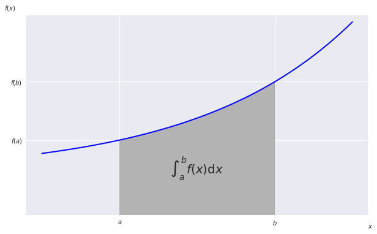

```python
from matplotlib.patches import Polygon
fig, ax = plt.subplots(figsize=(10, 6))
plt.plot(x, y, 'b', lw=2)
plt.ylim(bottom=0)
poly = Polygon(verts, facecolor='0.7', edgecolor='0.5')
ax.add_patch(poly) # 적분 영역을 회색 다각형으로 그립니다
plt.text(0.5 * (a + b), 1, r'$\int_a^b f(x)\mathrm{d}x$',
         horizontalalignment='center', fontsize=20) # 플롯 내부에 적분 공식 추가
plt.figtext(0.9, 0.075, '$x$')
plt.figtext(0.075, 0.9, r'$f\left(x\right)$')
ax.set_xticks((a, b))
ax.set_xticklabels(('$a$', '$b$'))
ax.set_yticks([func(a), func(b)])
ax.set_yticklabels(('$f(a)$', '$f(b)$'))
```

## 7.2 정적 3차원 플롯

금융 분야에서는 3차원 플롯을 사용할 분야가 많지는 않습니다. 그러나 변동성 곡면은 일련의 만기와 행사가 조합에 대한 내재 변동성을 나타낸 것으로 3차원 플롯이 필요합니다. 유러피안 콜 옵션의 가치 곡면과 베가 곡면은 [부록 B]를 참조하세요. 여기에서는 변동성 곡면과 유사한 플롯을 인위적으로 그려보겠습니다. 일단 다음과 같은 경우를 고려해보죠.

- 행사가는 50에서 150 사이
- 만기는 0.5년에서 2.5년 사이

이를 그리면 2차원 좌표 시스템이 됩니다. 넘파이의 `np.meshgrid()` 함수는 1차원 `ndarray` 객체 두 개에서 2차원 좌표를 생성합니다.

```python
strike = np.linspace(50, 150, 24) # 행사가 값 ndarray 객체
```

```python
ttm = np.linspace(0.5, 2.5, 24) # 만기 값 ndarray 객체
```

```python
strike, ttm = np.meshgrid(strike, ttm) # (가짜) 내재 변동성 값
```

```python
strike[:2].round(1)
```

```
array([[ 50. ,  54.3,  58.7,  63. ,  67.4,  71.7,  76.1,  80.4,  84.8,
         89.1,  93.5,  97.8, 102.2, 106.5, 110.9, 115.2, 119.6, 123.9,
        128.3, 132.6, 137. , 141.3, 145.7, 150. ],
       [ 50. ,  54.3,  58.7,  63. ,  67.4,  71.7,  76.1,  80.4,  84.8,
         89.1,  93.5,  97.8, 102.2, 106.5, 110.9, 115.2, 119.6, 123.9,
        128.3, 132.6, 137. , 141.3, 145.7, 150. ]])
```

```python
iv = (strike - 100) ** 2 / (100 * strike) / ttm # 더미는 변동성 값 암시
```

```python
iv[:5, :3]
```

```
array([[1.        , 0.76695652, 0.58132045],
       [0.85185185, 0.65333333, 0.4951989 ],
       [0.74193548, 0.56903226, 0.43130227],
       [0.65714286, 0.504     , 0.38201058],
       [0.58974359, 0.45230769, 0.34283001]])
```

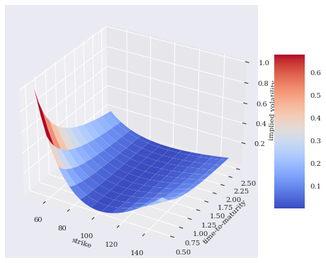

```python
from mpl_toolkits.mplot3d import Axes3D # 3차원 플롯 기능 임포트. Axes3D는 직접 사용하지 않아도 임포트해야 합니다.
fig, ax = plt.subplots(subplot_kw={'projection': '3d'}, figsize=(8, 8)) # 3차원 플롯 캔버스 설정
surf = ax.plot_surface(strike, ttm, iv, rstride=2, cstride=2,
                       cmap=plt.cm.coolwarm, linewidth=0.5,
                       antialiased=True)
ax.set_xlabel('strike')
ax.set_ylabel('time-to-maturity')
ax.set_zlabel('implied volatility')
fig.colorbar(surf, shrink=0.5, aspect=5)
```

아래 표는 `plot_surface` 함수의 인수 목록입니다.

| 인수 | 설명 |
| --- | --- |
| `X`, `Y`, `Z` | 2차원 배열 형식의 데이터 값 |
| `rstride` | 배열의 행 간격 |
| `cstride` | 배열의 열 간격 |
| `color` | 곡면 색깔 |
| `cmap` | 곡면에 사용될 컬러 맵 |
| `facecolors` | 개별 곡면 패치의 색 |
| `norm` | 값에서 색을 선택하는 데 사용되는 `Normalize` 객체 |
| `vmin` | 색으로 표시할 최소값 |
| `vmax` | 색으로 표시할 최대값 |
| `shade` | 그림자 표시 여부 |

2차원 플롯과 마찬가지로 라인 스타일은 점이나 삼각형 기호 등으로 대체할 수 있습니다. 아래 그림에서는 같은 자료를 3차원 스캐터플롯으로 표시하고 `view_init()` 함수를 사용하여 바라보는 각도를 변경했습니다.

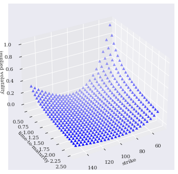

```python
fig = plt.figure(figsize=(10, 6))
ax = fig.add_subplot(111, projection='3d')
ax.view_init(30, 60) # 바라보는 각도 설정
ax.scatter(strike, ttm, iv, zdir='z', s=25,
           c='b', marker='^')
ax.set_xlabel('strike')
ax.set_ylabel('time-to-maturity')
ax.set_zlabel('implied volatility')
```

## 7.3 상호작용형 2차원 플롯

맷플롯립을 사용하면 정적인 비트맵 객체나 pdf 형식의 플롯을 만들 수 있습니다. 최근에는 D3.js 표준에 기반한 상호작용형 플롯을 생성하는 라이브러리도 많습니다. 이러한 플롯을 사용하면 확대 및 축소, 데이터 조사를 위한 호버(hover) 효과 등이 가능합니다. 이런 플롯은 보통 웹페이지에 쉽게 넣을 수 있습니다.  
`plotly`는 인기 있는 플랫폼이자 플롯 라이브러리입니다. 데이터 과학 전용으로 데이터 과학 커뮤니티에서 널리 쓰입니다. 주요 장점은 파이썬 생태계와 밀접하게 통합되어 있고 특히 판다스 `DataFrame` 객체 및 `Cufflinks` 패키지와 쉽게 연동하여 쓸 수 있다는 접입니다.  
일부 기능을 사용하려면 무료 계정이 필요합니다. 일단 비밀번호를 인증하면 컴퓨터에 저장하여 영구적으로 사용할 수 있습니다. 자세한 내용은 "파이썬으로 plotly 시작하기" 안내서(https://plot.ly/python/getting-started/)를 참조하세요.  
이 절은 일부 기능에만 초점을 맞춥니다. 주로 `Cufflinks`를 사용하여 `DataFrame` 객체에 저장된 자료를 상호작용형 플롯으로 만듭니다.

### 7.3.1 기본 플롯

주피터 노트북에서 사용하려면 몇 가지 임포트를 하고 노트북 모드를 켜야 합니다.

```python
import pandas as pd
import cufflinks as cf # Cufflinks 임포트
import plotly.offline as plyo # plotly의 오프라인 플롯 기능을 임포트
```

```python
plyo.init_notebook_mode(connected=True) # 노트북 모드 켜기
```

> **TIP** 원격 렌더링과 로컬 렌더링  
> `plotly`를 사용하면 플롯을 `plotly` 서버에서 렌더링할 수 있는 옵션이 있습니다. 하지만 대량의 데이터를 사용할 때는 일반적으로 노트북 모드가 훨씬 빠릅니다. 하지만 스트리밍 서비스와 같은 특정 기능은 서버와 통신해야 사용할 수 있습니다.

이 예제도 난수를 사용합니다. 난수는 `DatetimeIndex`을 가진 `DataFrame` 객체(시계열 데이터)에 저장됩니다.

```python
a = np.random.standard_normal((250, 5)).cumsum(axis=0)
```

```python
index = pd.date_range('2019-1-1', # 객체 시작일
                      freq='B', # 평일 주기
                      periods=len(a)) # 필요한 주기 개수
```

```python
df = pd.DataFrame(100 + 5 * a, # 원 데이터의 선형 변환
                  columns=list('abcde'), # 한 글자로 된 열 레이블
                  index=index) # DatetimeIndex 객체
```

```python
df.head()
```

|  | a | b | c | d | e |
| --- | --- | --- | --- | --- | --- |
| 2019-01-01 | 109.037535 | 98.693865 | 104.474094 | 96.878857 | 100.621936 |
| 2019-01-02 | 107.598242 | 97.005738 | 106.789189 | 97.966552 | 100.175313 |
| 2019-01-03 | 101.639668 | 100.332253 | 103.183500 | 99.747869 | 107.902901 |
| 2019-01-04 | 98.500363 | 101.208283 | 100.966242 | 94.023898 | 104.387256 |
| 2019-01-07 | 93.941632 | 103.319168 | 105.674012 | 95.891062 | 86.547934 |

`Cufflinks`는 `DataFrame` 클래스에 `df.iplot()` 메서드를 추가합니다. 이 메서드는 `plotly`를 백엔드로 써서 상호작용형 플롯을 만듭니다. 이 절의 모든 코드 예제는 상호작용형 플롯을 정적 비트맵으로 다운로드하는 옵션을 사용합니다. 이렇게 하면 글 사이에 그림을 넣을 수 있습니다. 주피터 노트북 환경에서 만들어진 그림은 모두 상호작용형입니다. 다음 코드로 만들어보죠.

```python
# 오프라인(노트북 모드) 기능 사용
plyo.iplot(df.iplot(asFigure=True), # asFigure 인수로 df.iplot()를 호출하면 로컬 플롯 가능
           # image='png', # 이미지 옵션은 플롯의 정적 비트맵 버전도 제공합니다.
           filename='ply_01') # 저장할 비트맵의 파일 이름이 지정(파일 확장자는 자동으로 추가됨)
```

[interactive chart not shown]

또한, 사용자가 바꿀 수 있는 다양한 옵션이 있습니다.

```python
plyo.iplot(df[['a', 'b']].iplot(asFigure=True,
                                theme='polar', # 테마 (플롯 스타일) 변경
                                title='A Time Series Plot', # 제목 추가
                                xTitle='date', # x축 레이블 추가
                                yTitle='value', # y축 레이블 추가
                                mode={'a':'markers', 'b':'lines+markers'}, # 열별로 플롯 모드 정의
                                symbol={'a':'circle', 'b':'diamond'}, # 열별로 사용할 기호 정의
                                size=3.5, # 모든 기호의 크기를 고정
                                colors={'a':'blue', 'b':'magenta'}, # 열별로 사용할 색상 정의
                                ),
           # image='png',
           filename='ply_02')
```

[interactive chart not shown]

맷플롯립과 유사하게 `plotly`도 다양한 플롯 유형을 제공합니다. 다음 코드의 결과를 라인이 아닌 히스토그램으로 나타내면 아래와 같습니다.

```python
plyo.iplot(df.iplot(kind='hist',
                    subplots=True,
                    bins=15,
                    asFigure=True),
           filename='ply_03')
```

[interactive chart not shown]

### 7.3.2 금융 플롯

`plotly`, `Cufflinks`, 맷플롯립을 조합하면 금융 시계열 데이터를 그리는 데 최고입니다. `Cufflinks`는 금융 플롯을 그리고 상대강도지수(Relative Strength Index, RSI)와 같은 금융 차트 요소를 추가하는 특수 기능을 제공합니다. 이를 위해 `Cufflinks`로 `DataFrame` 객체를 그릴 떄처럼 그림을 그릴 `QuantFig` 객체를 만듭니다. 여기에서는 실제 금융 데이터인 EUR/USD 환율 시계열 데이터를 사용합니다.

```python
raw = pd.read_csv('fxcm_eur_usd_eod_data.csv', index_col=0, parse_dates=True)
```

```python
raw.info()
```

```
<class 'pandas.core.frame.DataFrame'>
DatetimeIndex: 1547 entries, 2013-01-01 22:00:00 to 2017-12-31 22:00:00
Data columns (total 8 columns):
 #   Column    Non-Null Count  Dtype
---  ------    --------------  -----
 0   BidOpen   1547 non-null   float64
 1   BidHigh   1547 non-null   float64
 2   BidLow    1547 non-null   float64
 3   BidClose  1547 non-null   float64
 4   AskOpen   1547 non-null   float64
 5   AskHigh   1547 non-null   float64
 6   AskLow    1547 non-null   float64
 7   AskClose  1547 non-null   float64
dtypes: float64(8)
memory usage: 108.8 KB
```

```python
quotes = raw[['AskOpen', 'AskHigh', 'AskLow', 'AskClose']] # DataFrame 객체에서 4개의 열을 골라냅니다(시|고|저|종, OHLC)
quotes = quotes.iloc[-60:] # 일부 데이터 행만 시각화에 사용
quotes.tail()
```

|  | AskOpen | AskHigh | AskLow | AskClose |
| --- | --- | --- | --- | --- |
| 2017-12-25 22:00:00 | 1.18667 | 1.18791 | 1.18467 | 1.18587 |
| 2017-12-26 22:00:00 | 1.18587 | 1.19104 | 1.18552 | 1.18885 |
| 2017-12-27 22:00:00 | 1.18885 | 1.19592 | 1.18885 | 1.19426 |
| 2017-12-28 22:00:00 | 1.19426 | 1.20256 | 1.19369 | 1.20092 |
| 2017-12-31 22:00:00 | 1.20092 | 1.20144 | 1.19994 | 1.20144 |

초기화 과정에서 `QuantFig` 객체는 `DataFrame` 객체와 몇 가지 기본적인 사용자 인수를 받습니다. 그다음 `qf.iplot()` 메서드를 사용하여 `QuantFig` 객체 `qf`에 저장된 데이터를 플롯합니다.

```python
qf = cf.QuantFig(
    quotes, # QuantFig 생성자에 DataFrame 객체를 넣습니다.
    title='EUR/RSD Exchange Rate',
    legend='top',
    name='EUR/USD' # 데이터 집합 이름
    )
```

```python
plyo.iplot(
    qf.iplot(asFigure=True),
    # image = 'png',
    filename='qf_01'
)
```

[interactive chart not shown]

`QuantFig` 객체에 있는 다양한 메서드를 사용하여 볼린저 밴드(Bollinger bands)와 같은 차트 요소를 추가합니다.

```python
qf.add_bollinger_bands(periods=15, # 볼린저 밴드 기간 지정
                       boll_std=2) # 볼린저 밴드 표준편차 지정
```

```python
plyo.iplot(qf.iplot(asFigure=True),
           # image = 'png',
           filename='qf_02')
```

[interactive chart not shown]

RSI와 같은 금융지표는 서브플롯으로 추가합니다.

```python
qf.add_rsi(periods=14, # RSI 기간 변수 설정
           showbands=False) # 위아래 밴드 미표시 설정
```

```python
plyo.iplot(qf.iplot(asFigure=True),
           # image='png',
           filename='qf_03')
```

[interactive chart not shown]

## 7.4 마치며

맷플롯립 라이브러리는 파이썬 데이터 시각화에 관한 한 벤치마크이자 가장 많이 쓰이는 라이브러리입니다. 넘파이와 밀접하게 결합되어 있으며, 기본 사용 방법이 간단하고 쉽게 사용할 수 있습니다. 그러나 한편으로는 다소 복잡한 API를 제공하는 강력한 라이브러리이기도 합니다. 따라서 이 책의 한 챕터로 모든 기능을 살펴보는 것은 불가능합니다.  
이번 장에서는 금융 분야에서 유용할 만한 맷플롯립 라이브러리의 기본적인 2차원과 3차원 플롯 기능을 소개했습니다. 이후의 장에서 이 기본적인 시각화 라이브러리를 어떻게 사용하는지에 대해 추가적인 예제들을 제공할 것입니다.  
이 장에서는 `plotly`와 `Cufflinks`도 다루었습니다. 이 두 패캐지를 조합하면 `DataFrame` 객체에서 메서드만 호출해도 쉽게 상호작용형 D3.js 플롯을 생성할 수 있습니다. 모든 기술적인 사항은 백엔드에서 처리합니다. 또한 `Cufflinks`는 `QuantFig` 객체를 통해 일반적인 금융지표를 사용하여 전형적인 금융 플롯을 쉽게 생산하는 방법을 제공합니다.